# Permutation Tests (Part 1)

Stanford University, Spring 2016, STATS 205

## The Lady and the Tea

- Fisher starts his second chapter in his famous book on "The Design of Experiments" first published in 1935:
- Quote: `A lady declares that by tasting a cup of tea made with milk she can discriminate whether the milk or the tea infusion was first added to the cup.`
- Fisher proposed the the following experiment to test this
- Prepare eight cups of tea
- In four, add tea first
- In the other four, add milk first
- Hold constant other features of the cups of tea (size, temperature, etc.)
- Present cups in random order
- Lady tasts them and judges
- She knows that there are four of each type

## The Lady and the Tea

- Our theory is that the lady can taste the difference
- Which translates into our null hypothesis:  
  \(H_0:\) lady **cannot** taste difference
- The test statistics is the number of correct judgements
- Under the null all judgments are equally likely
- What is the null distribution of correct judgments?
- Once we have that compare it to the experiment and compute the probability of having observed the experimantal outcome or a more extreme case

## The Lady and the Tea

- Because of randomization, all \(8! = 40320\) permutations of the cups are equally likely, and each one has its own number of correct judgements
- There are \({8 \choose 4} = 70\) ways of choosing 4 cups from 8 cups
- Think of it as, choosing 4 cups in succession by first choosing from 8 cups, then 7, 6, 5, which gives \(8 \times 7 \times 6 \times 5 = 1680\)
- But by doing so, we have chosen not only every possible set of 4, but every possible set in every possible order
- Since 4 cups can be rearranged in order in \(4 \times 3 \times 2 \times 1 = 24\), we correct by \(1680/24 = 70\)

## The Lady and the Tea

```
##           [,1]  [,2]   [,3]   [,4]   [,5]  [,6]  [,7]   [,8]
## truth     "tea" "milk" "milk" "milk" "tea" "tea" "tea"  "milk"
## judgement "tea" "milk" "milk" "milk" "tea" "tea" "milk" "tea"
```

- Under the null, the reasons for the lady's judgements are unkown, except that they have nothing to do with the truth
- The judgements are what they are; they are fixed
- All \(70\) ways to line up cups are equally likely
- But only one line up will match the lady's judgements

## The Lady and the Tea

Of the four cups where the tea was poured first, select \(t\) of them to say "tea" correctly, and \(4−t\) to say "milk" incorrectly

```r
t = 0:4
probability = (choose(4,t)*choose(4,4-t))/choose(8,4)
data.frame(t=t,probability=round(probability,digits=3))
```

```
##   t probability
## 1 0       0.014
## 2 1       0.229
## 3 2       0.514
## 4 3       0.229
## 5 4       0.014
```

- The chances of a match is \(\frac{1}{70} = 0.014 < 0.05\)
- We need perfect match!

## The Lady and the Tea

Monte Carlo simulations

```r
judgement = c("tea","milk","milk","milk","tea","tea","milk","tea")
nSim = 10000
permutations = replicate(nSim,sample(8,replace = FALSE))
matches = apply(permutations,2,function(i) sum(judgement[i] == judgement))
data.frame(t=t,
           probability=round(probability,digits=3),
           monte=round(table(matches)/nSim,digits=3))
```

```
##   t probability monte.matches monte.Freq
## 1 0       0.014             0      0.013
## 2 1       0.229             2      0.224
## 3 2       0.514             4      0.518
## 4 3       0.229             6      0.230
## 5 4       0.014             8      0.015
```

## The Lady and the Tea

```r
t = 0:7
probability = (choose(7,t)*choose(7,7-t))/choose(14,7)
data.frame(t=t,probability=round(probability,digits=4))
```

```
##   t probability
## 1 0      0.0003
## 2 1      0.0143
## 3 2      0.1285
## 4 3      0.3569
## 5 4      0.3569
## 6 5      0.1285
## 7 6      0.0143
## 8 7      0.0003
```

- If she tasted 14 cups, it would be possible to reject \(H_0\) without requiring perfect judgement
- We need either perfect match or one miss to get a \(p\)-value below \(0.05\)

## Darwin and Fisher

- In chapter 3 of Fisher's book, he then introduced the first nonparametric test
- He illustrated his approach on data from Darwin
- Darwin raised cross- and self-fertilized corn (Zea mays) plants
- He planted equal numbers of each in four different pots, but not same number in each pot
- Darwin measured heights of plants when they were between 12 and 24 inches in height

## Darwin and Fisher

Original data (plant height in inches) from Darwin listed in Fisher's book

```
##    pair pot  cross   self   diff
## 1     1   1 23.500 17.375  6.125
## 2     2   1 12.000 20.375 -8.375
## 3     3   1 21.000 20.000  1.000
## 4     4   2 22.000 20.000  2.000
## 5     5   2 19.125 18.375  0.750
## 6     6   2 21.500 18.625  2.875
## 7     7   3 22.125 18.625  3.500
## 8     8   3 20.375 15.250  5.125
## 9     9   3 18.250 16.500  1.750
## 10   10   3 21.625 18.000  3.625
## 11   11   3 23.250 16.250  7.000
## 12   12   4 21.000 18.000  3.000
## 13   13   4 22.125 12.750  9.375
## 14   14   4 23.000 15.500  7.500
## 15   15   4 12.000 18.000 -6.000
```

## Darwin and Fisher

Fisher proceeds by testing the hypothesis  
\(H_0:\) No difference between crossed and self-fertilized plants

He peforms the paired sample \(t\)-test

```
##
##  Paired t-test
##
## data:  ZeaMays$cross and ZeaMays$self
## t = 2.148, df = 14, p-value = 0.0497
## alternative hypothesis: true difference in means is not equal to 0
## 95 percent confidence interval:
##  0.003899165 5.229434169
## sample estimates:
## mean of the differences
##                2.616667
```

## Darwin and Fisher

```r
ZeaMays$diff
```

```
##  [1]  6.125 -8.375  1.000  2.000  0.750  2.875  3.500  5.125  1.750  3.625
## [11]  7.000  3.000  9.375  7.500 -6.000
```

- Then he invents the first permutation test
- Under \(H_0\) that self-fertilized versus cross-fertilized does not matter, only chance determined whether \(A-B\) or \(B-A\)
- So the absolute value of the difference is what it is, but the plus or minus sign is by chance alone
- Test statistic is sum of the differences
- There are \(2^{15} = 32768\) ways to swap the plus and minus signs, all equaly likely under \(H_0\)
- Calculate statistic for each one to get null distribution

## Darwin and Fisher

- Random samples \(X_1,\dots,X_n\) from \(X\)
- Test \(H_0: E(X) = 0\)
- Write the usuall statistic as \[T = \sum_{i=1}^n X_i = \sum_{i=1}^n |X_i| \delta_i\]
- and split samples into two parts \[(|X_1|,\dots,|X_n|) \hspace{1cm}\text{and}\hspace{1cm} (\delta_1,\dots,\delta_n)\]
- Under \(H_0\) the two parts are independent and \(\delta_i\) is a fair coin flip \(\{-1,1\}\)
- The distribution of \(T\) is not well defined under \(H_0\)

## Darwin and Fisher

- But if we fix \(|X_i|\) at their observed values and regard \(\delta_i\) as random
- Then the condition null of \(T\) is well defined
- The only thing left to do is to compute \[P\left(T \ge t \, \big| \, H_0, |X_1|, \dots, |X_n| \right)\] by listing all possible samples of type \[\left(\pm \, |X_1|, \dots, \pm \, |X_n|\right)\]
- This is usually called the *Fisher's randomization test*
- Permutation tests describe a special case of randomization
- In permutation tests, we permute group labels on the observations

## Darwin and Fisher

Using Monte Carlo simulations

```r
nSim = 10000
n = length(ZeaMays$diff)
absDiff = abs(ZeaMays$diff)
signs = matrix(replicate(nSim*n,sample(c(-1,1),size=1)),nrow = nSim)
TNull = apply(signs,1,function(row) sum(row * absDiff))
T0 = sum(ZeaMays$diff)
pvalue = 2*mean(TNull >= T0); pvalue
```

```
## [1] 0.054
```

## Darwin and Fisher

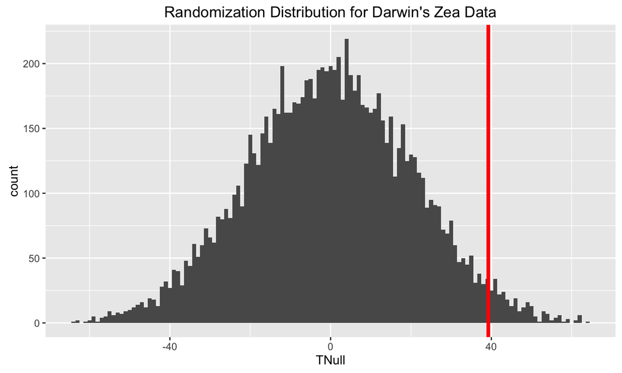

## Darwin and Fisher

- We already looked at similar tests
- The *sign test*:
  - Test statistic: \(S = \#_i \{ X_i \}\)
  - Wilcoxon signed-rank test: \(W = \sum_{i=1}^n \operatorname{R}(|X_i|) \delta_i\)
- In contrast to the randomization test, the Wilcoxon signed-rank test is not conditional on the ranks

## Permutation Test – General Recipe

- Decide on a test statistic \(T\)
- List the possible values of \(T\)
- Under \(H_0\), all ways of re-arranging the data are equally likely
- \(P(T = t)\) is proportional to the number of ways of getting the value \(t\)
- The permutation \(p\)-value is the probability of getting a value of \(T\) as extreme or more extreme as the value we observed, "extreme" meaning in a direction inconsistent with \(H_0\)

## Permutation Test – One-Sample Problem

- Location model: \(X_i = \theta + e_i\)
- Assume error distribution has symmetric pdf \(f(t)\) around \(\theta\)
- Hypothesis test: \(H_0: \theta = 0\) versus \(H_A: \theta > 0\)
- Test statistic: Sum of deviations of \(\theta\) about \(0\)
- Under null, positive and negative deviations cancel each other out, so sum should be close to zero
- We reject the null in favor of alternative if sum is "large"
- To find what large means we comaper to null distribution using permutation
- What to permute?
- We use principle of *sufficiency*

## Permutation Test – One-Sample Problem

- Assume that we had lost the signs information
- Under the null, we can recover the orginal distribution by randomly assigning signs to each deviation
- In this case, we say that the deviations are sufficient
- Under the alternative of a location parameter larger than zero, randomizing the signs of the deviations should reduce the sum from what it was originally
- List all possible reassignments of plus and minus signs \(2^n\)
- Compare observed sum with all possible sums

## Permutation Test – Two-Sample Problem

- Test statistic: Sum of observations from second population
- Assume that we had lost the group assignments
- Under the null, we can recover the original distribution by randomly assigning groups to each observation
- In this case, we say that the observations (without group labels) are sufficient
- Under the alternative one group will have a larger sum
- List all possible group reassignments and compute sum of second population
- Compare observed sum to all possible sums

## Assumption: Exchangeable Observations

- A sufficient condition for permutation test is exchangeable of observations
- Consider a collection of random variables \[ X_1,\dots,X_n \]
- If their joint distribution are equal under permuations \(\pi\) \[P_{X_1,\dots,X_n}(A) = P_{X_{\pi(1)},\dots,X_{\pi(n)}}(A)\]
- then \(X_1,\dots,X_n\) are called exchangable
- This is a weaker assumption than indepdendence of observations in the combined sample

## Assumption: Exchangeable Observations

- Some examples:
- Independent and identically distributed observations are exchangeable
- Samples without replacement from a finite population are exchangeable:
  - An urn contains \(b\) black balls, \(r\) red balls, \(y\) yellow balls, and so forth
  - A series of balls are extracted from the urn
  - After the \(i\)th extraction, the color of the ball \(X_i\) is noted and \(k\) balls of the same color are added to the urn,
  - where \(k\) can be any integer, positive, negative, or zero
  - The set of random events \(\{X_i\}\) form an exchangeable sequence
- Dependent normally distributed random variables \(\{X_i\}\) for which the variance of \(X_i\) is a constant independent of \(i\) and the covariance of \(X_i\) and \(X_j\) is a constant independent of \(i\) and \(j\)

## Assumption: Exchangeable Observations

- Sometimes a simple transformation will ensure that observations are exchangeable
- For example, if we know that \(X\) comes from a population with mean \(\mu\) and distribution \(F(x−\mu)\) and
- an independent observation \(Y\) comes from a population with mean \(v\) and distribution \(F(x−v)\)
- then the independent variables \(X'=X−\mu\) and \(Y'=Y−v\) are exchangeable

## How to Compute It?

- Small sample size:  
  Enumerations of all permutations using Gray codes  
  (takes expotional time in \(n\))
- Medium sample size:  
  Fast Frourier Transform  
  (takes polynomial time in \(n\))
- Large sample size:  
  Monte Carlo simulations  
  (time depends on accuracy requirements)

## References

- Good (2005). Permutations, Parametric, and Boostrap Test of Hypothesis
- Basu (1980). Randomization Analysis of Experimential Data: The Fisher Randomization Test
- Pagano and Tritchler (1983). On Obtaining Permutation Distributions in Polynomial Time
- Diaconis And Holmes (1994). Gray Codes for Randomization Procedures